# Predictions

## Statistical Model Background

Statistical models of stream temperature often rely on the close relationship between air temperature and water temperature. However, this relationship breaks down during the winter in temperature zones, particularly as streams freeze, thereby changing their thermal and properties. Many researchers and managers are interested in the non-winter effects of temperature. The winter period, when phase change and ice cover alter the air-water relationship, differs in both time (annually) and space. We developed an index of air-water synchrony ($Index_{sync}$) so we can model the portion of the year that it not affected by freezing properties. The index is the difference between air and observed water temperatures divided by the water temperature plus 0.000001 to avoid division by zero.

We calculate the $Index_{sync}$ for each day of the year at each reach for each year with observed data. We then calculate the 99.9% confidence interval of $Index_{sync}$ for days between the 125 and 275 days of the year (05 May and 02 October). Then moving from the middle of the year (day 180) to the beinging of the year, we searched for the first time when 10 consecutive days were not within the 99.9% CI. This was selected as the spring breakpoint. Similarly moving from the middle to the end of the year, the first event with fewer than 16 consecutive days within the 99.9% CI was assigned as the autumn breakpoint. Independent breakpoints were estimated for each reach-year combination. For reach-years with insufficient data to generate continuous trends and confidence intervals, we used the mean break points across years for that reach. If there was not sufficient local reach information, we used the mean breakpoints from the smallest hydrologic unit the reach is nested in (i.e. check for mean from HUC12, then HUC10, HUC8, etc.). More details regarding the identification of the synchronized period can be found in Letcher et al. (*in review*). The portion of the year between the spring and autumn breakpoints was used for modeling the non-winter, approximately ice-free stream temperatures.

We used a generalized linear mixed model to account for correlation in space (stream reach nested within HUC8). This allowed us to incorporate short time series as well as long time series from different reaches and disjunct time series from the same reaches without risk of pseudoreplication (ref: Hurlbert). By limited stream drainage area to <400 $km^2$ and only modeling the synchronized period of the year, we were able to use a linear model, avoiding the non-linearities that occur at very high temperatures due to evaporative cooling and near 0 C dur to phase change (ref: mohseni).

We assumed stream temperature measurements were normally distributed following,

$t_{h,r,y,d} \sim \mathcal{N}(\mu_{h,r,y,d}, \sigma)$

where $t_{h,r,y,d}$ is the observed stream water temperature at the reach ($r$) within the sub-basin identified by the 8-digit Hydrologic Unit Code (HUC8; $h$) for each day ($d$) in each year ($y$). We describe the normal distribution based on the mean ($mu_{h,r,y,d}$) and standard deviation ($\sigma$) and assign a vague prior of $\sigma = 100$. The mean temperature is modelled to follow a linear trend

$\omega_{h,r,y,d} = X_0 B_0 + X_{h,r,d} B_{h,r} + X_{h,d} B_{h} + X_{y,d} B_{y}$

but the expected mean temperature ($\mu_{h,r,y,d}$) was also adjusted based on the residual error from the previous day

$\mu_{h,r,y,d} = \begin{cases} \omega_{h,r,y,d} + \delta_{r}(t_{h,r,y,d-1} - \omega_{h,r,y,d-1}) & \quad \text{for $t_{h,r,y,d-1}$ is real} \\ \omega_{h,r,y,d} & \quad \text{for $t_{h,r,y,d-1}$ is not real} \end{cases}$

where $\delta_{r}$ is an autoregressive [AR(1)] coefficient that varies randomly by reach and $\omega_{h,r,y,d}$ is the expected temperature before accounting for temporal autocorrelation in the error structure.

$X_{0}$ is the $n \times K_0$ matrix of predictor values. $B_0$ is the vector of $K_0$ coefficients, where $K_0$ is the number of fixed effects parameters including the overall intercept.

# Predictions

**Pick a catchment based on featureid:**

```r
# featureid with observed data
id1 <- "730912"

# featureid without observed data in a huc with data
id2 <- "831619"

# featureid without observed data in a huc without any data
id3 <- "767093"
```

### Pull Landscape & Land-use Data Associated with particular `featureid`

All spatial information in the database is centered around the `featureid`. Select the `featureid` or IDs of interest for the prediction. Then pull the associated landscape and land-use information (basin characteristics). Information on these metrics can be found in the GitHub repo: https://github.com/Conte-Ecology/basinCharacteristics.

```r
# connect to database
drv <- dbDriver("PostgreSQL")
con <- dbConnect(drv, dbname="sheds", host='ecosheds.org', user=options('SHEDS_USERNAME'), password=options('SHEDS_PASSWORD'))


param_list <- c("forest",
              "herbaceous",
              "agriculture",
              "devel_hi",
              "developed",
              "AreaSqKM",
              "allonnet",
              "alloffnet",
              "surfcoarse",
              "srad",
              "dayl",
              "swe")

param_list_string <- paste(shQuote(param_list), collapse = ", ")
featureid_list_string <- paste(shQuote(c(id1, id2, id3)), collapse = ", ")

qry_covariates <- paste0("SELECT * FROM covariates WHERE zone='upstream' AND variable IN (", param_list_string, ") AND featureid IN (", featureid_list_string, ") ;") # could add AreaSqKM <400
rs <- dbSendQuery(con, qry_covariates)
df_covariates_long <- fetch(rs, n=-1)
```

The covariate data is stored in long format in the sheds database. I then convert it to wide format in R.

```r
# show long format data structure
str(df_covariates_long)
```

```
## 'data.frame':    27 obs. of  4 variables:
##  $ featureid: int  730912 730912 730912 730912 730912 730912 730912 730912 730912 767093 ...
##  $ variable : chr  "agriculture" "alloffnet" "allonnet" "AreaSqKM" ...
##  $ value    : num  44.02 1.61 13.9 18.41 0 ...
##  $ zone     : chr  "upstream" "upstream" "upstream" "upstream" ...
```

```r
# convert from long to wide format
df_covariates_upstream <- tidyr::spread(df_covariates_long, variable, value)

# show wide format data structure
str(df_covariates_upstream)
```

```
## 'data.frame':    3 obs. of  11 variables:
##  $ featureid  : int  730912 767093 831619
##  $ zone       : chr  "upstream" "upstream" "upstream"
##  $ agriculture: num  44 0 0
##  $ alloffnet  : num  1.613 0.814 0.509
##  $ allonnet   : num  13.899 0.326 0.381
##  $ AreaSqKM   : num  18.41 4.42 1.42
##  $ devel_hi   : num  0 0 0
##  $ developed  : num  1.89 0 1.53
##  $ forest     : num  44.3 99.5 98.5
##  $ herbaceous : num  9.817 0.468 0
##  $ surfcoarse : num  0 0.183 10.172
```

```r
head(df_covariates_upstream)
```

```
##   featureid     zone agriculture alloffnet  allonnet AreaSqKM devel_hi
## 1    730912 upstream     44.0158  1.613380 13.899500  18.4086        0
## 2    767093 upstream      0.0000  0.813835  0.325534   4.4235        0
## 3    831619 upstream      0.0000  0.508582  0.381437   1.4157        0
##   developed  forest herbaceous surfcoarse
## 1   1.88716 44.2798   9.817150   0.000000
## 2   0.00000 99.5320   0.467955   0.183113
## 3   1.52575 98.4743   0.000000  10.171600
```

### Get HUC info

Get HUC information for the desired covariates and join to the covariate dataframe

```r
qry_huc <- paste0("SELECT featureid, huc12 FROM catchment_huc12 WHERE featureid IN (", featureid_list_string, ");")

rs <- dbSendQuery(con, statement = qry_huc)
df_huc <- fetch(rs, n=-1)

df_huc <- df_huc %>%
  dplyr::mutate(HUC4=str_sub(huc12, 1, 4),
                HUC8=str_sub(huc12, 1, 8),
                HUC10=str_sub(huc12, 1, 10),
                huc = as.character(HUC8)) %>% # huc = HUC8 for legacy code reasons
  dplyr::rename(HUC12 = huc12)

str(df_huc)
```

```
## 'data.frame':    3 obs. of  6 variables:
##  $ featureid: int  730912 767093 831619
##  $ HUC12    : chr  "010100030301" "041505000102" "010802010603"
##  $ HUC4     : chr  "0101" "0415" "0108"
##  $ HUC8     : chr  "01010003" "04150500" "01080201"
##  $ HUC10    : chr  "0101000303" "0415050001" "0108020106"
##  $ huc      : chr  "01010003" "04150500" "01080201"
```

### Pull Temporal Data (from daymet)

Pulling from the daymet records is the most time consuming piece of doing predictions (at least in R). We have daily meteorological data via daymet for 1980-2013. Therefore, we can predict daily stream temperatures for that time period. In the future, it may be useful to use Scott Steinschneider’s weather generator to create air temperature and precipitation time series for alternative scenarios or future conditions.

```r
year <- 2009
# Efficient Query of data from 1 year using date column: http://stackoverflow.com/questions/9186741/sql-query-where-dates-year-is-year
date_start <- shQuote("2009-01-01")
date_end <- shQuote("2009-12-31")
qry_daymet <- paste0("SELECT featureid, date, tmax, tmin, prcp, dayl, srad, vp, swe, (tmax + tmin) / 2.0 AS airTemp FROM daymet WHERE featureid IN (", featureid_list_string, ") AND date BETWEEN ", date_start, "AND ", date_end, ";")

rs <- dbSendQuery(con, statement = qry_daymet)
df_daymet <- fetch(rs, n=-1)

str(df_daymet)
```

```
## 'data.frame':    1095 obs. of  10 variables:
##  $ featureid: int  730912 730912 730912 730912 730912 730912 730912 730912 730912 730912 ...
##  $ date     : Date, format: "2009-01-01" "2009-01-02" ...
##  $ tmax     : num  -14.94 -10.83 -10.36 -7.42 -5 ...
##  $ tmin     : num  -21.5 -20.6 -21.1 -17.5 -15.5 ...
##  $ prcp     : num  0 0 0 0 1 0 8 11.5 0 0 ...
##  $ dayl     : num  30067 30067 30067 30413 30413 ...
##  $ srad     : num  90.8 127.8 138.8 132.6 138.5 ...
##  $ vp       : num  120 120 120 160 200 160 120 160 200 120 ...
##  $ swe      : num  64 64 64 64 64.2 ...
##  $ airtemp  : num  -18.2 -15.7 -15.7 -12.4 -10.2 ...
```

```r
head(df_daymet)
```

```
##   featureid       date      tmax     tmin prcp    dayl     srad  vp
## 1    730912 2009-01-01 -14.94440 -21.5278    0 30067.2  90.8444 120
## 2    730912 2009-01-02 -10.83330 -20.5556    0 30067.2 127.8220 120
## 3    730912 2009-01-03 -10.36110 -21.0556    0 30067.2 138.8440 120
## 4    730912 2009-01-04  -7.41667 -17.4722    0 30412.8 132.6220 160
## 5    730912 2009-01-05  -5.00000 -15.5000    1 30412.8 138.4890 200
## 6    730912 2009-01-06  -6.50000 -16.5833    0 30412.8 134.7560 160
##       swe   airtemp
## 1 64.0000 -18.23611
## 2 64.0000 -15.69444
## 3 64.0000 -15.70833
## 4 64.0000 -12.44444
## 5 64.2222 -10.25000
## 6 64.2222 -11.54167
```

Apparently my SQL code isn’t case sensitive when creating `airTemp` so I have to rename it from `airtemp` to `airTemp` to match the rest of my code.

```r
df_daymet <- df_daymet %>%
  dplyr::rename(airTemp = airtemp)
```

### Calculate derived parameters

There are some parameters that are derived from those in the database such as 2-day precip sum, previous 7-day mean air temperature, day of the year.

```r
  df_daymet <- df_daymet %>%
    group_by(featureid) %>% # only necessary when doing for multiple featureid
    arrange(featureid, date) %>% # make sure sorted in order
    mutate(airTempLagged1 = lag(airTemp, n = 1, fill = NA),
           temp7p = rollapply(data = airTempLagged1,
                              width = 7,
                              FUN = mean,
                              align = "right",
                              fill = NA,
                              na.rm = T),
           prcp2 = rollsum(x = prcp, 2, align = "right", fill = NA),
           prcp7 = rollsum(x = prcp, 7, align = "right", fill = NA),
           prcp30 = rollsum(x = prcp, 30, align = "right", fill = NA),
           dOY = yday(date))
```

### Clip to Synchronized Time Period

We just model data for the period of the year where air and water temperatures are relatively synchronized (free of ice and snow-melt influences). For now it’s probably just easiest to do predictions from 01 May through 01 October since that period will be synchronized in almost every year for all sites from Virginia to Maine. This could be done in the daymet query above, but for flexibility I filter the data here. Also the full annual time series is used for calculating things like the 30-day precip.

```r
df_daymet_sync <- df_daymet %>%
  dplyr::mutate(month = month(date)) %>%
  dplyr::filter(month >= 05 & month < 10 )
```

### Pull Observed Data if Available

The raw data are stored in the database. These are often subdaily temperatures and they have not undergone full QAQC. You could pull directly from the database and reduce to daily mean temperatures. The alternative, which I’m employing right now, is to just use the observed data that I used for model fitting (calibration). For the web applications, we’d likely want to have site-specific values anywhere there is data. Therefore, in the future I could do a model run without holding out any data for validation (assuming that the past validations are sufficient if the model hasn’t changed and the general extent of the data haven’t changed).

The observed temperatures I use are stored in the `tempDataSync` dataframe with the column heading `temp`.

```r
df_obs <- tempDataSync %>%
  dplyr::select(featureid, date, temp)
```

### Combine independent and dependent data

```r
df_master <- df_daymet_sync %>%
  dplyr::left_join(df_covariates_upstream) %>%
  dplyr::left_join(df_huc) %>%
  dplyr::left_join(df_obs)
```

It will be important to check if there are any predictors with missing data. If so, the temperature cannot be predicted. This is the case for a few random areas (NH White Mountains) and the edges of the mapped delineation (Canadian border). The model is also only valid for streams with drainage areas < 400 km^2. Larger drainages don’t get predictions (assign `NA`).

```r
all(df_master$AreaSqKM < 400)
```

```
## [1] TRUE
```

### Standardize Covariates (independent data)

Example of standardization file and conversion to standardized values. For each variable of interest (variables used in the model excluding interactions are stored in the `var.names` dataframe which is loaded with `tempDataSync.RData`).

```
## 'data.frame':    19 obs. of  3 variables:
##  $ var.names: chr  "airTemp" "temp7p" "prcp" "prcp2" ...
##  $ means    : num  17.27 17.28 4.07 8.14 28.29 ...
##  $ stdevs   : num  5.62 5.2 9.12 14.54 29.39 ...
```

```
##   var.names      means    stdevs
## 1   airTemp  17.268314  5.616548
## 2    temp7p  17.278260  5.196645
## 3      prcp   4.069246  9.124358
## 4     prcp2   8.139136 14.544795
## 5     prcp7  28.291626 29.385973
## 6    prcp30 120.297272 65.808224
```

```
##  [1] TRUE TRUE TRUE TRUE TRUE TRUE TRUE TRUE TRUE TRUE TRUE TRUE TRUE TRUE
## [15] TRUE TRUE TRUE TRUE TRUE
```

```
## Classes 'grouped_df', 'tbl_df', 'tbl' and 'data.frame':  459 obs. of  33 variables:
##  $ featureid     : int  730912 730912 730912 730912 730912 730912 730912 730912 730912 730912 ...
##  $ date          : Date, format: "2009-05-01" "2009-05-02" ...
##  $ tmax          : num  17.5 13.9 13.6 16.4 16.7 ...
##  $ tmin          : num  3 2.14 0 1 -2.5 ...
##  $ prcp          : num  0.18116 -0.00759 -0.44598 -0.44598 -0.44598 ...
##  $ dayl          : num  0.441 0.506 0.506 0.572 0.572 ...
##  $ srad          : num  0.783 0.406 2.084 2.336 2.728 ...
##  $ vp            : num  760 720 600 640 480 ...
##  $ swe           : num  7.79 7.64 7.55 7.42 7.35 ...
##  $ airTemp       : num  -1.25 -1.65 -1.87 -1.52 -1.81 ...
##  $ airTempLagged1: num  5.6 10.25 8.03 6.79 8.72 ...
##  $ temp7p        : num  -1.78 -1.69 -1.8 -1.86 -1.78 ...
##  $ prcp2         : num  -0.166 0.109 -0.285 -0.56 -0.56 ...
##  $ prcp7         : num  -0.768 -0.632 -0.632 -0.632 -0.632 ...
```

[output cut: 21 more lines]

```
## Source: local data frame [6 x 33]
## Groups: featureid
##
##   featureid       date    tmax     tmin         prcp      dayl        srad
## 1    730912 2009-05-01 17.5000  3.00000  0.181160615 0.4408614  0.78320658
## 2    730912 2009-05-02 13.9167  2.13889 -0.007589113 0.5063963  0.40594751
## 3    730912 2009-05-03 13.5833  0.00000 -0.445976143 0.5063963  2.08357572
## 4    730912 2009-05-04 16.4444  1.00000 -0.445976143 0.5719312  2.33563263
## 5    730912 2009-05-05 16.7222 -2.50000 -0.445976143 0.5719312  2.72791520
## 6    730912 2009-05-06 12.4444  2.25000  0.065475758 0.6374661 -0.04475773
## Variables not shown: vp (dbl), swe (dbl), airTemp (dbl), airTempLagged1
##   (dbl), temp7p (dbl), prcp2 (dbl), prcp7 (dbl), prcp30 (dbl), dOY (dbl),
##   month (dbl), zone (chr), agriculture (dbl), alloffnet (dbl), allonnet
##   (dbl), AreaSqKM (dbl), devel_hi (dbl), developed (dbl), forest (dbl),
##   herbaceous (dbl), surfcoarse (dbl), HUC12 (chr), HUC4 (chr), HUC8 (chr),
##   HUC10 (chr), huc (chr), temp (dbl)
```

### Get list of covariates and calculate interation terms

I’m not sure the best way to get the list of interaction terms. I have hard coded as many interactions as I could think of and calculate all of them every time then just use the ones I want in the model.

I only use interactions in the fixed effects (except day of the year squared and cubed which will always be used), so they can be extracted by looking for the names with dots.

```r
cov_list$fixed.ef
```

```
##  [1] "intercept"           "airTemp.forest"      "airTemp.prcp2.da"
##  [4] "airTemp.devel_hi"    "airTemp.prcp30.da"   "allonnet"
##  [7] "allonnet2"           "airTemp.allonnet"    "airTemp.allonnet2"
## [10] "airTemp.agriculture"
```

```r
(interactions <- filter(as.data.frame(cov_list$fixed.ef, stringsAsFactors = FALSE), grepl("\\.", cov_list$fixed.ef))[["cov_list$fixed.ef"]])
```

```
## [1] "airTemp.forest"      "airTemp.prcp2.da"    "airTemp.devel_hi"
## [4] "airTemp.prcp30.da"   "airTemp.allonnet"    "airTemp.allonnet2"
## [7] "airTemp.agriculture"
```

```r
# if you always calculate these interactions you can then just use the subset of them which match those used in the model

addInteractions <- function (data)
{
  data <- data %>%
    dplyr::mutate(intercept = 1, intercept.site = 1,
                  intercept.year = 1,
                  dOY2 = dOY^2,
                  dOY3 = dOY^3,
                  airTemp.forest = airTemp * forest,
                  airTemp.prcp2.da = airTemp * prcp2 * AreaSqKM,
                  airTemp.prcp2.da.forest = airTemp * prcp2 * AreaSqKM * forest,
                  airTemp.prcp30.da = airTemp * prcp30 * AreaSqKM,
                  airTemp.agriculture = airTemp * agriculture,
                  airTemp.devel_hi = airTemp * devel_hi,
                  temp7p.forest = temp7p * forest,
                  temp7p.prcp7.da = temp7p * prcp7 * AreaSqKM,
                  temp7p.forest.prcp7.da = temp7p * forest * prcp7 * AreaSqKM,
                  srad.forest = srad * forest,
                  airTemp.swe = airTemp * swe,
                  airTemp.allonnet = airTemp * allonnet,
                  airTemp.alloffnet = airTemp * alloffnet,
                  allonnet2 = allonnet * allonnet,
                  airTemp.allonnet2 = airTemp * allonnet * allonnet,
                  devel_hi.prcp2.da = devel_hi * prcp2 * AreaSqKM,
                  agriculture.prcp2.da = agriculture * prcp2 * AreaSqKM)
  return(data)
}


df_master_std = addInteractions(data = df_master_std)
df_master_std <- as.data.frame(unclass(df_master_std))
# str(df_master_std)
# df_master_std[1, ]
```

### Assign Conditional or Marginal Coefficient Estimates for Random Effects

Example of covariate list:

```
## List of 4
##  $ fixed.ef: chr [1:10] "intercept" "airTemp.forest" "airTemp.prcp2.da" "airTemp.devel_hi" ...
##  $ site.ef : chr [1:2] "intercept.site" "airTemp"
##  $ huc.ef  : chr [1:2] "intercept.site" "airTemp"
##  $ year.ef : chr [1:4] "intercept.year" "dOY" "dOY2" "dOY3"
```

Example of coeficient data:

```
## List of 15
##  $ fix.ef    :Classes 'tbl_df', 'tbl' and 'data.frame':  17 obs. of  6 variables:
##   ..$ Parameter: Factor w/ 3081 levels "B.0[1]","B.0[2]",..: 1 2 3 4 5 6 7 8 9 10 ...
##   ..$ mean     : num [1:17] 19.04898 0.02859 0.00413 0.04013 -0.00903 ...
##   ..$ sd       : num [1:17] 0.24082 0.02321 0.00186 0.01651 0.00371 ...
##   ..$ qLo      : num [1:17] 18.571877 -0.017291 0.000393 0.008331 -0.016264 ...
##   ..$ qHi      : num [1:17] 19.54369 0.07368 0.00779 0.07304 -0.00155 ...
##   ..$ coef     : chr [1:17] "intercept" "airTemp.forest" "airTemp.prcp2.da" "airTemp.devel_hi" ...
##  $ B.fixed   :Classes 'tbl_df', 'tbl' and 'data.frame':  10 obs. of  6 variables:
##   ..$ Parameter: chr [1:10] "B.0[1]" "B.0[2]" "B.0[3]" "B.0[4]" ...
##   ..$ mean     : num [1:10] 19.04898 0.02859 0.00413 0.04013 -0.00903 ...
##   ..$ sd       : num [1:10] 0.24082 0.02321 0.00186 0.01651 0.00371 ...
##   ..$ qLo      : num [1:10] 18.571877 -0.017291 0.000393 0.008331 -0.016264 ...
##   ..$ qHi      : num [1:10] 19.54369 0.07368 0.00779 0.07304 -0.00155 ...
##   ..$ coef     : chr [1:10] "intercept" "airTemp.forest" "airTemp.prcp2.da" "airTemp.devel_hi" ...
##  $ mu.huc    :Classes 'tbl_df', 'tbl' and 'data.frame':  2 obs. of  7 variables:
##   ..$ Parameter: Factor w/ 3081 levels "B.0[1]","B.0[2]",..: 3046 3047
##   ..$ mean     : num [1:2] 0 1.98
##   ..$ sd       : num [1:2] 0 0.0536
##   ..$ qLo      : num [1:2] 0 1.88
##   ..$ qHi      : num [1:2] 0 2.09
##   ..$ index    : num [1:2] 1 2
##   ..$ coef     : Factor w/ 2 levels "airTemp","intercept.site": 2 1
##  $ mu.year   :Classes 'tbl_df', 'tbl' and 'data.frame':  4 obs. of  7 variables:
##   ..$ Parameter: Factor w/ 3081 levels "B.0[1]","B.0[2]",..: 3048 3049 3050 3051
##   ..$ mean     : num [1:4] 0 -0.05479 -2.41046 0.00131
##   ..$ sd       : num [1:4] 0 0.1006 0.1377 0.0708
##   ..$ qLo      : num [1:4] 0 -0.263 -2.691 -0.134
##   ..$ qHi      : num [1:4] 0 0.14 -2.142 0.147
##   ..$ index    : num [1:4] 1 2 3 4
##   ..$ coef     : Factor w/ 4 levels "dOY","dOY2","dOY3",..: 4 1 2 3
##  $ mu.ar1    :Classes 'tbl_df', 'tbl' and 'data.frame':  1 obs. of  6 variables:
##   ..$ Parameter: Factor w/ 3081 levels "B.0[1]","B.0[2]",..: 3045
##   ..$ mean     : num 0.881
##   ..$ sd       : num 0.00769
##   ..$ qLo      : num 0.867
##   ..$ qHi      : num 0.897
##   ..$ coef     : Factor w/ 3081 levels "B.0[1]","B.0[2]",..: 3045
##  $ sigma.site:Classes 'tbl_df', 'tbl' and 'data.frame':  2 obs. of  7 variables:
##   ..$ Parameter: Factor w/ 3081 levels "B.0[1]","B.0[2]",..: 3076 3077
```

[output cut: 59 more lines]

```
##   ..$ sd       : num [1:84] 0.335 0.366 0.367 0.203 0.304 ...
##   ..$ qLo      : num [1:84] -0.2139 -0.4613 -0.0367 0.3858 -0.6995 ...
##   ..$ qHi      : num [1:84] 1.085 1 1.438 1.168 0.482 ...
##   ..$ index    : num [1:84] 1 2 3 4 5 6 7 8 9 10 ...
##   ..$ index2   : num [1:84] 1 1 1 1 1 1 1 1 1 1 ...
##   ..$ year     : chr [1:84] "1991" "1992" "1994" "1995" ...
##   ..$ coef     : chr [1:84] "intercept.year" "intercept.year" "intercept.year" "intercept.year" ...
##  $ B.ar1     :Classes 'tbl_df', 'tbl' and 'data.frame':  952 obs. of  7 variables:
##   ..$ Parameter: chr [1:952] "B.ar1[1]" "B.ar1[2]" "B.ar1[3]" "B.ar1[4]" ...
##   ..$ mean     : num [1:952] 0.899 0.853 0.891 0.877 0.878 ...
##   ..$ sd       : num [1:952] 0.0611 0.076 0.0648 0.0727 0.0762 ...
##   ..$ qLo      : num [1:952] 0.764 0.691 0.751 0.719 0.706 ...
##   ..$ qHi      : num [1:952] 0.992 0.982 0.994 0.991 0.992 ...
##   ..$ index    : num [1:952] 1 2 3 4 5 6 7 8 9 10 ...
##   ..$ site     : chr [1:952] "730482" "730531" "730675" "730912" ...
```

### Calculate Trend

check if featureid in list of featureid with specific (conditional) site-level effects. This will help to decide which coefficients to choose, the site-specific or the mean. In the following example, I will do it for the first featureid (`id1`). The sites (featureid) with specific coefficients are listed in `coef_list$B.site$site`. If it is, then pull the specific coefficient estimates from `B.site` and `B.ar1` which both vary by featureid (site), otherwise use the means, which in the case of random site effects are 0 by definition but not for ar1.

```r
id_site_specific <- id1 %in% coef_list$B.site$site

if(id_site_specific == TRUE) {
  B.site <- dplyr::filter(coef_list$B.site, site == id1)
  B.ar1 <- dplyr::filter(coef_list$B.ar1, site == id1)
} else {
  B.site <- data.frame(mean = rep(0, times = length(cov_list$site.ef)))
  B.ar1 <- coef_list$mu.ar1$mean
}

B.site
```

```
## Source: local data frame [2 x 9]
##
##     Parameter        mean        sd        qLo        qHi index index2
## 1 B.site[4,1] -2.14496728 0.7565011 -3.6177715 -0.6224001     4      1
## 2 B.site[4,2] -0.05756802 0.3516605 -0.7450916  0.6064669     4      2
## Variables not shown: site (chr), coef (chr)
```

```r
B.ar1
```

```
## Source: local data frame [1 x 7]
##
##   Parameter      mean         sd       qLo       qHi index   site
## 1  B.ar1[4] 0.8770791 0.07271085 0.7194012 0.9913213     4 730912
```

Get huc effects

```r
hucid <- df_huc[which(df_huc$feature == id1), ]$huc
id_huc_specific <- hucid %in% coef_list$B.huc$huc

if(id_huc_specific == TRUE) {
  B.huc <- dplyr::filter(coef_list$B.huc, huc == hucid)
} else {
  B.huc <- coef_list$mu.huc$mean
}

# B.huc
```

Get year effects (need to pick a year in which to predict earlier)

```r
yearid <- year # rename because of scoping problem in dplyr
id_year_specific <- year %in% coef_list$B.year$year

if(id_year_specific == TRUE) {
  B.year <- dplyr::filter(coef_list$B.year, year == yearid)
} else {
  B.year <- coef_list$mu.year$mean
}

# B.year
```

Get fixed effects (B.0)

```r
B.0 <- coef_list$B.fixed

B.0
```

```
## Source: local data frame [10 x 6]
##
##    Parameter         mean          sd           qLo          qHi
## 1     B.0[1] 19.048984729 0.240816141 18.5718770680 19.543693996
## 2     B.0[2]  0.028590947 0.023209113 -0.0172914549  0.073683449
## 3     B.0[3]  0.004129137 0.001857343  0.0003926374  0.007791944
## 4     B.0[4]  0.040127066 0.016512182  0.0083305227  0.073036839
## 5     B.0[5] -0.009032962 0.003710029 -0.0162636670 -0.001553009
## 6     B.0[6]  0.968966099 0.085284592  0.8009388355  1.135429498
## 7     B.0[7] -0.207162624 0.038496771 -0.2808386310 -0.130778254
## 8     B.0[8]  0.034039350 0.023487111 -0.0122015339  0.080610955
## 9     B.0[9] -0.047760611 0.011028779 -0.0692804095 -0.026369386
## 10   B.0[10]  0.006911997 0.015650921 -0.0243744792  0.037924431
## Variables not shown: coef (chr)
```

Separate the data into matrices by fixed effects, site effects, huc effects, and year effects

```r
# just cycle through data for the 1 featureid of interest
df_master_std1 <- dplyr::filter(df_master_std, featureid == id1)

X.0 <- dplyr::select(df_master_std1, one_of(B.0$coef))
X.site <- dplyr::select(df_master_std1, one_of(as.character(coef_list$B.site$coef)))
X.huc <- dplyr::select(df_master_std1, one_of(as.character(coef_list$B.huc$coef)))
X.year <- dplyr::select(df_master_std1, one_of(as.character(coef_list$B.year$coef)))

str(X.0)
```

```
## 'data.frame':    153 obs. of  10 variables:
##  $ intercept          : num  1 1 1 1 1 1 1 1 1 1 ...
##  $ airTemp.forest     : num  2.03 2.68 3.04 2.48 2.94 ...
##  $ airTemp.prcp2.da   : num  -0.133 0.115 -0.34 -0.545 -0.648 ...
##  $ airTemp.devel_hi   : num  0.412 0.542 0.614 0.501 0.596 ...
##  $ airTemp.prcp30.da  : num  -0.403 -0.482 -0.619 -0.712 -0.929 ...
##  $ allonnet           : num  1 1 1 1 1 ...
##  $ allonnet2          : num  1 1 1 1 1 ...
##  $ airTemp.allonnet   : num  -1.25 -1.65 -1.87 -1.53 -1.81 ...
##  $ airTemp.allonnet2  : num  -1.26 -1.65 -1.87 -1.53 -1.82 ...
##  $ airTemp.agriculture: num  -8.24 -10.85 -12.3 -10.03 -11.92 ...
```

```r
str(X.site)
```

```
## 'data.frame':    153 obs. of  2 variables:
##  $ intercept.site: num  1 1 1 1 1 1 1 1 1 1 ...
##  $ airTemp       : num  -1.25 -1.65 -1.87 -1.52 -1.81 ...
```

```r
str(X.huc)
```

```
## 'data.frame':    153 obs. of  2 variables:
##  $ intercept.site: num  1 1 1 1 1 1 1 1 1 1 ...
##  $ airTemp       : num  -1.25 -1.65 -1.87 -1.52 -1.81 ...
```

```r
str(X.year)
```

```
## 'data.frame':    153 obs. of  4 variables:
##  $ intercept.year: num  1 1 1 1 1 1 1 1 1 1 ...
##  $ dOY           : num  -1.62 -1.6 -1.58 -1.56 -1.55 ...
##  $ dOY2          : num  2.63 2.57 2.51 2.45 2.39 ...
##  $ dOY3          : num  -4.26 -4.11 -3.97 -3.83 -3.7 ...
```

Loop through to calculate expected temperature timeseries (trend before accounting for temporal autocorrelation)

```r
temp_expected <- rep(NA, times = nrow(df_master_std1))
for(i in 1:nrow(df_master_std1)) { # loop through time (each row = a date for the given featureid)
  t.fixed <- 0
  for(j in 1:nrow(B.0)) { # loop through fixed effects
    foo <- B.0[j, "mean"] * X.0[i,j]
    t.fixed <- foo + t.fixed
  }
    t.site <- 0
  for(k in 1:nrow(B.site)) { # loop through fixed effects
    foo <- B.site[k, "mean"] * X.site[i,k]
    t.site <- foo + t.site
  }
      t.huc <- 0
  for(l in 1:nrow(B.huc)) { # loop through fixed effects
    foo <- B.huc[l, "mean"] * X.huc[i,l]
    t.huc <- foo + t.huc
  }
        t.year <- 0
  for(m in 1:nrow(B.year)) { # loop through fixed effects
    foo <- B.year[m, "mean"] * X.year[i,m]
    t.year <- foo + t.year
  }
  temp_expected[i] <- as.numeric(t.fixed + t.site + t.huc + t.year)
}

summary(temp_expected)
```

```
##    Min. 1st Qu.  Median    Mean 3rd Qu.    Max.
##   7.571  11.180  13.600  13.230  15.590  18.360
```

### Add Autoregressive Error

Now you have the expected stream temperatures for a site (featureid) for each day within the generally synchronized period of the year. I’m not sure how you want to handle updating these with corrections for the temporal autocorrelation. The autocorrelation coefficient (`B.ar1`) varies by site (`featureid`), which is why I included it above in the `ifelse` statement to get the appropriate `B.ar1` estimate and if not available for that site, then I assigned it the mean value across all sites.

Essentially, what you do to add the autoregressive part is test whether there is observed temperature data from the previous day. If so then calculate the residual for that day (observed - expected) multiply it by the autoregressive coefficient and add the value to today’s expected temperature (I believe before updating yesterday’s to account for the autoregressive but I’ll double check). It might be helpful to test whether there is any data for that site on the dates for prediction because if not, there’s no need to go through the daily loop.

```r
temp_pred <- rep(NA, times = nrow(df_master_std1))
if(any(!is.na(df_master_std1)) == TRUE) {
  temp_pred[1] <- temp_expected[1]
  for(i in 2:nrow(df_master_std1)) { # loop through each day
    if(!is.na(df_master_std1$temp[i-1])) { # check if previous day had observed stream temperature data
      temp_pred[i] = temp_expected[i] + B.ar1$mean * (df_master_std1$temp[i-1] - temp_expected[i-1])
    } else { # else if no observed data yesterday
      temp_pred[i] <- temp_expected[i]
    }
  }
} else { # else if no observed temp data for any days just use the expected for all predictions
  temp_pred <- temp_expected
} # end outer ifelse any data statement

summary(temp_pred)
```

```
##    Min. 1st Qu.  Median    Mean 3rd Qu.    Max.
##   7.571  11.180  13.600  13.090  15.390  18.140
```

### Plot Predictions

- Blue = predicted stream temperature
- Black = observed stream temperature

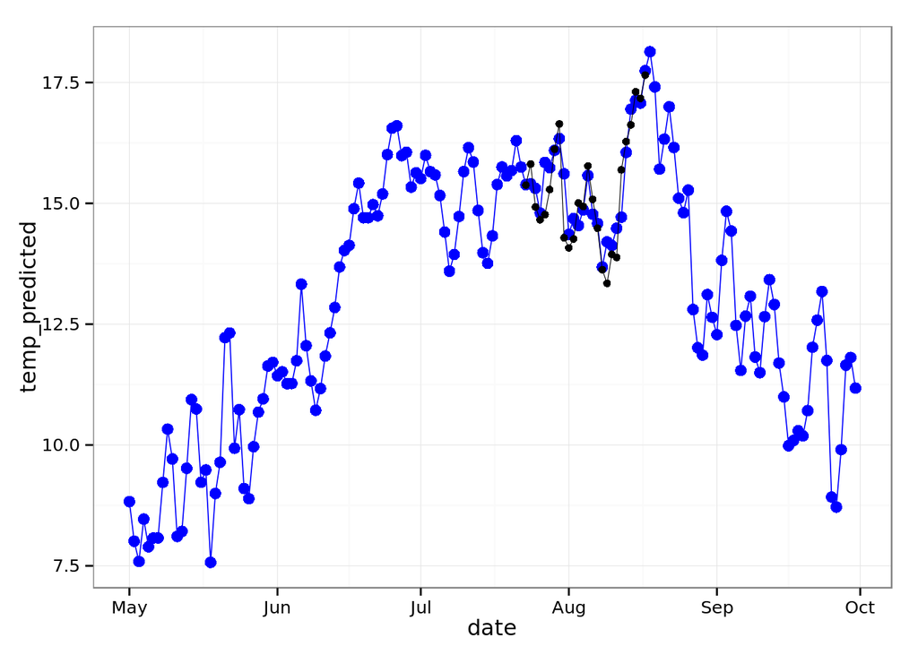

```r
library(ggplot2)
df <- data.frame(featureid = id1, date = df_master_std1$date, temp_observed = df_master_std1$temp, temp_expected = temp_expected, temp_predicted = temp_pred)

ggplot(df, aes(date, temp_predicted)) + geom_point(colour = 'blue', size = 3) + geom_line(colour = 'blue', size = 0.3) + geom_point(aes(date, df_master_std1$temp), colour = 'black', size = 2) + geom_line(aes(date, df_master_std1$temp), colour = 'black', size = 0.2)  + theme_bw()
```

### Save predictions for featureid to csv

```r
write.csv(df, file = "predictions.csv", row.names = FALSE)
```